# Chapter 18 Notes

**Chapter 18 Notes - Electrochemistry**

Electrochemistry: the study of the interchange of chemical

and electrical energy

Oxidation reduction (redox) reaction: involves a transfer of

electrons from the reducing agent to the oxidizing agent

Oxidation: loss of electrons

Reduction: gain of electrons

Reducing agent: electron donor

Oxidizing agent: electron acceptor

The Half–Reaction method for balancing equations for

oxidation–reduction reactions in acidic solutions:

1. Write separate equations for the oxidation and reduction half–reactions.
2. For each half–reaction:
   1. Balance all the elements except H and O.
   2. Balance O using H<sub>2</sub>O.
   3. Balance H using H<sup>+</sup>.
   4. Balance the charge using electrons.
3. If necessary, multiply one or both balanced half–reactions by an integer to equalize the number of electrons transferred in the two half–reactions.
4. Add the half–reactions, and cancel identical species.
5. Check that the elements and charges are balanced.

Ex: Cr<sub>2</sub>O<sub>7</sub><sup>2-</sup>(aq) + SO<sub>3</sub><sup>2-</sup>(aq) Cr<sub>3</sub><sup>+</sup>(aq) + SO<sub>4</sub><sup>2-</sup>(aq)

Cr<sub>2</sub>O<sub>7</sub><sup>2-</sup> -> Cr<sub>3</sub><sup>+</sup> , 14H<sup>+</sup> + 6e<sup>-</sup> + Cr<sub>2</sub>O<sub>7</sub><sup>2</sup>- -> Cr<sup>3+</sup> + 7H<sub>2</sub>O

SO<sub>3</sub><sup>2-</sup> -> SO<sub>4</sub><sup>2-</sup> , 3[H<sub>2</sub>O + SO<sub>3</sub><sup>2-</sup> -> SO<sub>4</sub><sup>2-</sup> + 2e<sup>-</sup> + 2H<sup>+</sup>]

The Half–Reaction method for balancing equations for oxidation–reduction reactions in basic solutions:

1. Use the half–reaction method as specified for acidic solutions to obtain the final balanced equation as if H<sup>+</sup> ions were present.
2. To both sides of the equation obtained above, add a number of OH<sup>–</sup> ions that is equal to the number of H<sup>+</sup> ions. (We want to eliminate H<sup>+</sup> by forming H<sub>2</sub>O.)
3. Form H<sub>2</sub>O on the side containing both H<sup>+</sup> and OH<sup>–</sup> ions, and eliminate the number of H<sub>2</sub>O molecules that appear on both sides of the equation.
4. Check that elements and charges are balanced.

**Galvanic Cell**: A device in which chemical energy is changed to electrical energy. Uses a spontaneous redox reaction to produce a current

that can be used to do work.

- Oxidation occurs at the anode.
- Reduction occurs at the cathode.
- Salt bridge or porous disk – devices that allow ions to flow without extensive mixing of the solutions.
- Salt bridge – contains a strong electrolyte held in a Jello–like matrix.
- Porous disk – contains tiny passages that allow hindered flow of ions.
- A galvanic cell consists of an oxidizing agent in one compartment that pulls electrons through a wire from a reducing agent in the other compartment.
- The “pull”, or driving force, on the electrons is called the cell potential (E<sub>cell</sub>), or the electromotive force (emf) of the cell. (Unit of electrical potential is the volt - V)
- When a half-reaction is reversed, the sign of E° is reversed.
- When a half-reaction is multiplied by an integer, E° remains the same.
- A galvanic cell runs spontaneously in the direction that gives a positive value for E°<sub>cell</sub>.

Line Notation:

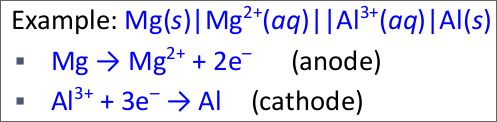

Maximum Cell Potential:

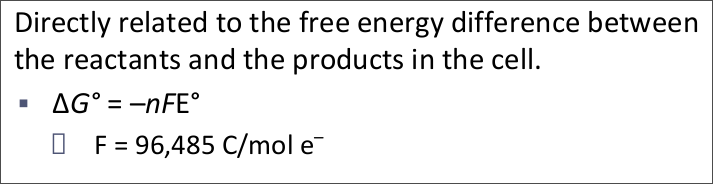

**Nernst Equation**: The relationship between cell potential and

concentrations of cell components

E = E° - (RT / nF)ln(Q) , where R is the universal gas constant, T is temp (K), n is the ion charge (moles of electrons transferred), and F is the Faraday constant (same as above: 96,485 C/mol e<sup>-</sup>).

**Corrosion**: Process of returning metals to their natural state – the ores from which they were originally obtained. Involves oxidation of the metal.

**Electrolysis**: Forcing a current through a cell to produce a chemical change for which the cell potential is negative.

[figure not shown]